# Eksploracja danych geoprzestrzennych

Redukcja wymiarowości

Author

Krzysztof Dyba

# Wprowadzenie

Wariancja jest to miara statystyczna, która opisuje ilościowo zróżnicowanie (rozrzut) wartości w zbiorze danych, określając jak bardzo odbiegają od wartości średniej tego zbioru. Wysoka wariancja wskazuje, że punkty są rozproszone, podczas gdy niska wariancja oznacza, że są one skupione blisko średniej. Zerowa wariancja oznacza, że wszystkie wartości są identyczne (brak zmienności). Należy pamiętać, że wariancja wyrażona jest w jednostkach kwadratowych ($j^2$) oryginalnych danych, co może sprawić, że interpretacja będzie mniej intuicyjna. Z tego powodu często preferowane jest odchylenie standardowe, tj. pierwiastek kwadratowy z wariancji.

```r
# wariancja dla próby
sum((x - mean(x))^2 / (length(x) - 1))
```

W analizie danych wariancja traktowana jest jako miara ilości informacji. Przyjmuje się, że im większa zmienność danej cechy, tym więcej istotnych informacji ona niesie. W rzeczywistych zbiorach danych często spotykamy się z ogromną liczbą cech (zmiennych), które opisują pewne obserwacje (obiekty). Jest to tak zwane zjawisko wielowymiarowości danych (*high dimensionality*). W praktyce, powoduje to problemy związane z ilością wymaganej pamięci do przetwarzania danych, dłuższym czasem obliczeń, trudnościami w interpretacji zależności i ich wizualizacją w przestrzeni dwuwymiarowej, a także zmniejszenie skuteczności modelu wraz ze wzrostem liczby zmiennych (słabsza generalizacja zależności).

Rozwiązaniem tych problemów może być zastosowanie **analizy głównych składowych** (*principal component analysis*, PCA), która jest najczęściej stosowaną metodą do redukcji wymiarowości. Przekształca ona zbiór danych ze skorelowanymi zmiennymi w nowy zbiór nieskorelowanych (ortogonalnych) zmiennych nazywanymi głównymi składowymi (*principal components*), zachowując przy tym jak najwięcej zmienności (informacji). Główne składowe są liniowymi kombinacjami oryginalnych zmiennych, uporządkowanymi według ilości wariancji, którą wyjaśniają. Oznacza to, że pierwsza główna składowa (PC1) wyjaśnia największą zmienność (wariancję), a każda kolejna składowa (PC2, PC3, itd.) mniej. Jeśli główna składowa nie wykazuje prawie żadnej wariancji, to ma ona niewielki wkład w reprezentację zbioru danych i z tego powodu jest wykluczana z dalszej analizy.

Analiza głównych składowych umożliwia przede wszystkim zmniejszenie liczby zmiennych w zbiorze danych i usunięcie współliniowości między nimi. Oprócz tego, przydatna jest do wizualizacji danych wielowymiarowych w dwóch wymiarach wykorzystując najczęściej dwie najistotniejsze główne składowe (PC1 i PC2).

Technika ta wymaga spełnienia kilku założeń:

1. Relacje między zmiennymi są liniowe.
2. Dane są typu ilościowego (dane jakościowe wymagają odpowiedniego kodowania).
3. Wszystkie obserwacje mają wartości (brak `NA` w zbiorze danych).
4. Ograniczenie wpływu wartości odstających, ponieważ zniekształcają wyniki.
5. Zmienne muszą posiadać jednakowe skale (wymagana standaryzacja danych).

Niemniej, nie jest to jedyne podejście do redukcji wymiarowości. Wyróżnić można także skalowanie wielowymiarowe (*multidimensional scaling*), autoenkodery oparte na sieciach neuronowych czy techniki służące wyłącznie do wizualizacji, takie jak *t-SNE* i *UMAP*.

# Analiza danych tabelarycznych

```r
library("corrplot")
```

## Przygotowanie danych

Analizę przeprowadzimy na przykładzie danych społeczno-ekonomicznych z [World Bank Data](https://data.worldbank.org/). Dla uproszczenia przyjmijmy, że interesują nas wyłącznie kraje europejskie.

```r
# wczytanie danych w formacie .csv
data = read.csv2("../dane/world_bank_data.csv")
# selekcja krajów europejskich
data = data[data$region == "EU" & !is.na(data$region), ]
# wyświetlenie struktury danych
str(data)
```

```
'data.frame':   47 obs. of  12 variables:
 $ country   : chr  "Albania" "Andorra" "Austria" "Belarus" ...
 $ region    : chr  "EU" "EU" "EU" "EU" ...
 $ code      : chr  "ALB" "AND" "AUT" "BLR" ...
 $ gdp       : num  3.27e+10 NA 4.12e+11 1.68e+11 4.96e+11 ...
 $ pop       : int  2889167 70473 8611088 9513000 11285721 3810416 7177991 163692 4224404 1165300 ...
 $ pop_growth: num  1.07 3.06 0.36 0.27 0.38 0.31 -0.17 0.74 0.04 1.3 ...
 $ internet  : num  63.3 96.9 83.9 62.2 85.1 65.1 56.7 NA 69.8 71.7 ...
 $ urban_pop : num  27.3 NA 30.9 26.3 18.5 21 23.1 NA 27.6 NA ...
 $ life_exp  : num  77.8 NA 81.3 73 80.6 76.4 75.4 80.6 77.3 80.1 ...
 $ literacy  : num  96.8 NA NA 99.7 NA ...
 $ export_gdp: num  0.271 NA 0.534 0.601 0.844 ...
 $ gdp_pc    : num  11305 NA 47824 17661 43992 ...
```

Jak możemy zauważyć powyżej, w naszej ramce danych mamy liczne wartości brakujące `NA` (w szczególności w kolumnie `literacy`), co uniemożliwi nam wykonanie analizy głównych składowych. Zatem musimy je usunąć.

```r
# usuń całą kolumnę
data$literacy = NULL
```

```r
# usuń wiersze z brakującymi wartościami
idx = complete.cases(data)
data = data[idx, ]
```

Poglądowo sprawdźmy również ogólną korelację liniową pomiędzy zmiennymi.

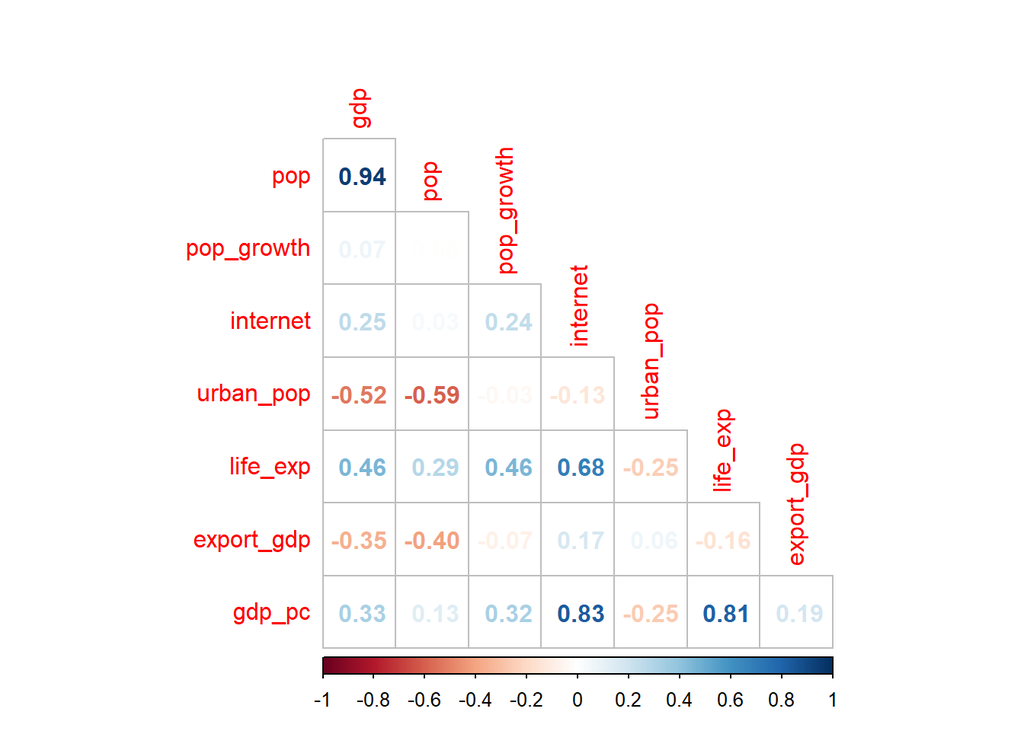

```r
# macierz korelacji
cor_mat = cor(data[, 4:11], method = "pearson")
corrplot(cor_mat, method = "number", type = "lower", diag = FALSE)
```

Najsilniejsza korelacja występuję pomiędzy całkowitą populacją kraju a produktem krajowym brutto (PKB). Wynika to z prostego związku, iż PKB mierzy wartość wszystkich dóbr i usług wytworzonych w gospodarce w danym okresie, a większa liczba ludności zwiększa produkcję oraz konsumpcję. Kolejna silna zależność występuje pomiędzy produktem krajowym brutto na osobę a dostępem do internetu i spodziewaną długością życia. Pozostałe zmienne nie wykazuje aż tak silnych zależności.

Analiza głównych składowych jest wrażliwa na skalę zmiennych, dlatego ważne jest uprzednie ustandaryzowanie danych, tj. wyśrodkowanie (poprzez odjęcie średniej) i przeskalowanie (poprzez podzielenie przez odchylenie standardowe). Zapewnia to, że zmienne o większej skali nie zdominują pozostałych zmiennych. Do standaryzacji danych służy funkcja `scale()`.

```r
# skalowanie danych
data_scale = scale(data[4:11])
```

Po tej operacji średnia wartość każdej zmiennej wynosi 0, a odchylenie standardowe jest równe 1.

## Analiza głównych składowych

Do analizy głównych składowych można wykorzystać między innymi funkcję `prcomp()`. Jeśli dokonaliśmy wcześniej standaryzacji danych, to koniecznie musimy nadać argumentom `scale.` i `center` wartość `FALSE`, aby uniknąć podwójnej standaryzacji.

```r
pca = prcomp(data_scale, scale. = FALSE, center = FALSE)
summary(pca)
```

```
Importance of components:
                          PC1    PC2    PC3     PC4     PC5     PC6     PC7
Standard deviation     1.8263 1.4490 1.0349 0.84846 0.65724 0.46883 0.30846
Proportion of Variance 0.4169 0.2624 0.1339 0.08998 0.05399 0.02748 0.01189
Cumulative Proportion  0.4169 0.6794 0.8133 0.90323 0.95723 0.98470 0.99659
                           PC8
Standard deviation     0.16507
Proportion of Variance 0.00341
Cumulative Proportion  1.00000
```

W podsumowaniu wyników otrzymujemy:

- Odchylenie standardowe (*Standard deviation*) – wskazuje istotność każdej głównej składowej (im większa wartość, tym większa istotność).
- Proporcja wariancji (*Proportion of Variance*) – proporcja całkowitej wariancji wyjaśniona przez każdą główną składową.
- Proporcja skumulowana (*Cumulative Proportion*) – skumulowana część wariancji wyjaśniona przez pierwsze $k$ głównych składowych.

Dodatkowo, otrzymaliśmy dwa obiekty `rotation` i `x`. Ten pierwszy reprezentuje macierz ładunków (*loadings*), natomiast drugi zawiera nowe wartości obserwacji po transformacji rzutowane na główne składowe (można je później wykorzystać do modelowania).

```r
# macierz ładunków PC1 i PC2
pca$rotation[, 1:2]
```

```
                  PC1        PC2
gdp         0.4263113  0.3668460
pop         0.3563355  0.4905988
pop_growth  0.2100404 -0.2323769
internet    0.3709802 -0.3990428
urban_pop  -0.3091641 -0.2715945
life_exp    0.4668035 -0.2207007
export_gdp -0.1106244 -0.3903555
gdp_pc      0.4287361 -0.3696659
```

Ładunki informują, w jakim stopniu każda zmienna wejściowa ma wpływ na każdą główną składową, tzn. wysoka wartość ładunku w pierwszej składowej głównej oznacza, że jest silnie skorelowana z tą składową. Natomiast znak wskazuje kierunek zależności.

Dla przykładu, zmienne `life_exp`, `gdp` oraz `gdp_pc` mają wysoki dodatni ładunek na pierwszej składowej (PC1), oznacza to, że ta składowa jest silnie zależna od tych zmiennych. Zobaczymy jak wygląda zależność pomiędzy pierwszą główną składową (PC1) a zmienną `gdp` na wykresie rozrzutu.

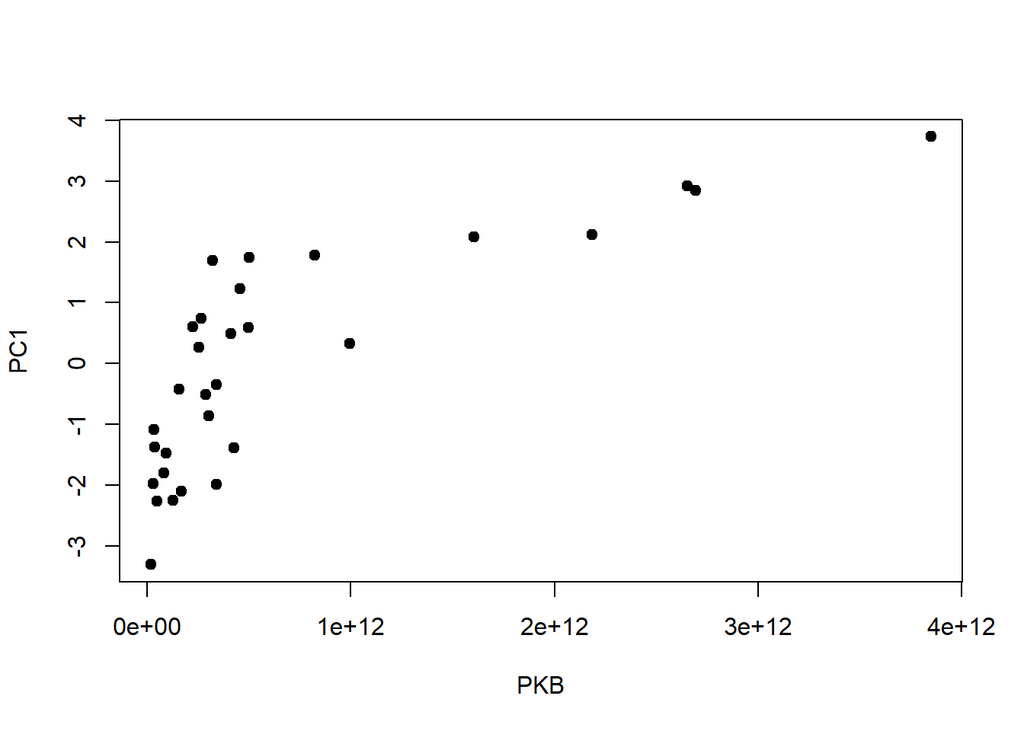

```r
plot(data$gdp, pca$x[, 1], pch = 19, xlab = "PKB", ylab = "PC1")
```

## Interpretacja

Najważniejszym krokiem jest zrozumienie, w jaki sposób interpretować otrzymane wyniki. W tym celu będą pomocne dwa wykresy.

### Wykres piargowy

Wykres piargowy (*scree plot*) to wykres wyjaśnionej wariancji dla każdej głównej składowej. Pomaga określić, ile głównych składowych należy zachować do dalszej analizy. Punkt przegięcia, tzw. “łokieć” wykresu zazwyczaj wskazuje punkt, w którym dodanie większej liczby składowych w niewielkim stopniu przyczynia się do ogólnej wyjaśnionej wariancji. Aby go wyświetlić wystarczy użyć funkcji `plot()` na obiekcie klasy `prcomp`.

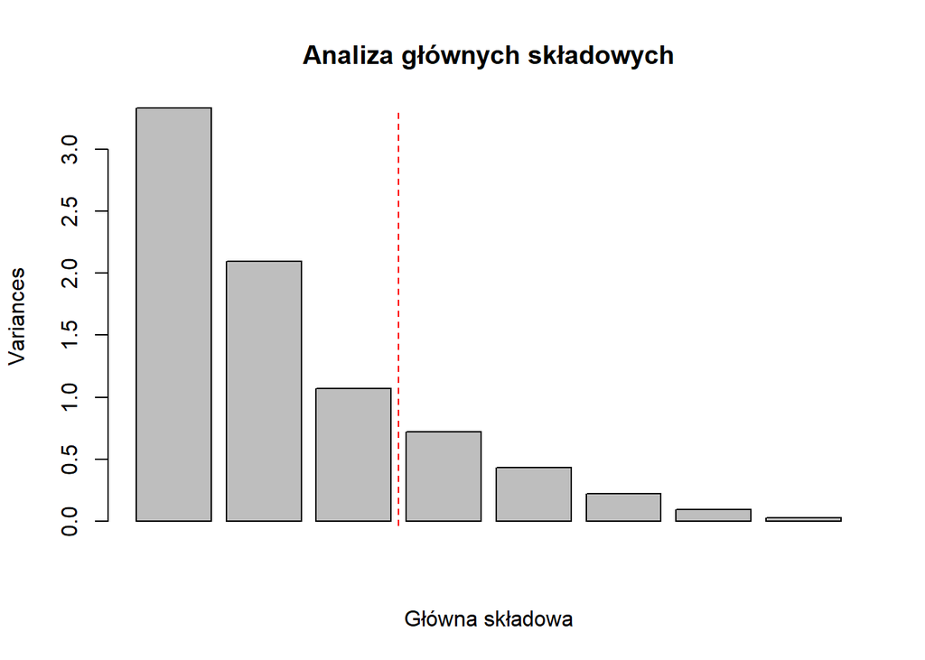

```r
plot(pca, main = "Analiza głównych składowych", xlab = "Główna składowa")
abline(v = 3.7, lty = 2, col = "red")
```

Powyższy wykres sugeruje, że powinniśmy zachować pierwsze trzy główne składowe, które wyjaśniają ponad 80% zmienności w danych. Dodanie czwartej głównej składowej pozwoliłoby na wyjaśnienie ponad 90% zmienności. Pozostałe składowe reprezentują mniejszą ilość informacji (zasadniczo jest to szum w danych).

### Biplot

Biplot to wykres punktowy przedstawiający rzutowane obserwacje na wybrane główne składowe oraz strzałki reprezentujące ładunki oryginalnych zmiennych, które tworzą pewne kąty. Jeśli wartość kąta pomiędzy strzałkami jest bliska:

- 0° to zmienne są silnie dodatnio skorelowane.
- 180° to zmienne są również silnie skorelowane, ale przeciwnie.
- 90° to zmienne są niezależne (ortogonalne).

Biplot można stworzyć używając funkcji `biplot()` na obiekcie klasy `prcomp`. Argument `choices` pozwoli nam wybrać główne składowe.

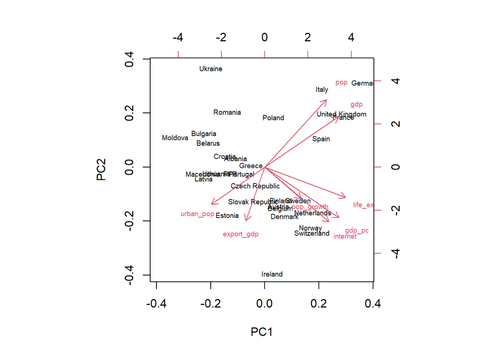

```r
biplot(pca, choices = 1:2, cex = 0.6, xlabs = data$country)
```

W przypadku większych zbiorów danych, składających się z minimum kilkuset obserwacji, odczytanie ich nazw nie będzie możliwe. W takiej sytuacji warto zamienić etykiety nazw na kropki, ustawiając argument `xlabs = rep("·", nrow(data))`. Alternatywnie, można całkowicie je pominąć i interpretować jedynie położenie głównych składowych.

Niemniej, interpretacja głównych składowych jest skomplikowanym procesem. Z tego powodu warto rozważyć najprostsze techniki redukcji wymiarowości oparte na usuwaniu cechy o bliskiej zeru wariancji (mała zmienność to mało informacji) oraz cech, które są ze sobą silnie skorelowane (np. korelacja powyżej 90%), aby zmniejszyć redundancję danych.

# Analiza danych przestrzennych

```r
library("terra")
```

W tej sekcji zastosujemy redukcję wymiarowości do danych przestrzennych, a wynik zaprezentujemy na mapie. Zacznijmy od wylistowania rastrów, które mamy dostępne w katalogu `dane` używając funkcji `list.files()`. Doprecyzujmy, że interesują nas wyłącznie pliki rastrowe z rozszerzeniem `.tif`.

```r
# listowanie plików w folderze
files = list.files("../dane/", pattern = "\\.tif$", full.names = TRUE)
files = files[1:3]
```

Następnie używając funkcji `rast()` możemy wczytać wybrane trzy warstwy jako jeden raster wielokanałowy, tj. składający się z trzech warstw. Pamiętaj, żeby stworzyć raster wielokanałowy, to poszczególne warstwy muszą posiadać tę samą geometrię (liczba kolumn i wierszy), zakres przestrzenny oraz układ przestrzenny!

```r
# wczytanie rastrów
r = rast(files)
r
```

```
class       : SpatRaster
size        : 270, 300, 3  (nrow, ncol, nlyr)
resolution  : 100, 100  (x, y)
extent      : 345000, 375000, 493000, 520000  (xmin, xmax, ymin, ymax)
coord. ref. : ETRF2000-PL / CS92 (EPSG:2180)
sources     : 01_roughness.tif
              02_green.tif
              03_distwaters.tif
names       : 01_roughness,  02_green, 03_distwaters
min values  :    -0.163727, -0.004931,      1.873463
max values  :    25.983419,  0.769584,   8061.545898
```

Wybrane rastry zostały wczytane jako obiekt `r`. Kolejne kroki analizy wykonamy na mniejszej próbie losowej. Takie podejście stosuje się w przypadku przetwarzania ogromnych zbiorów danych, ponieważ nie jest możliwe, aby wczytać je do pamięci komputera. Do losowania próby służy funkcja `spatSample()`, w której możemy zdefiniować jej wielkość oraz usuwanie brakujących wartości `NA`. Szczególnie ważne jest zadbanie o powtarzalność analizy, więc koniecznie jest wcześniejsze zdefiniowanie ziarna losowości `set.seed()`.

```r
# ziarno losowości
set.seed(1)
# losowanie próby
smp = spatSample(r, size = 5000, na.rm = TRUE, as.points = TRUE)
```

Teraz możemy wyświetlić wylosowane punkty na mapie.

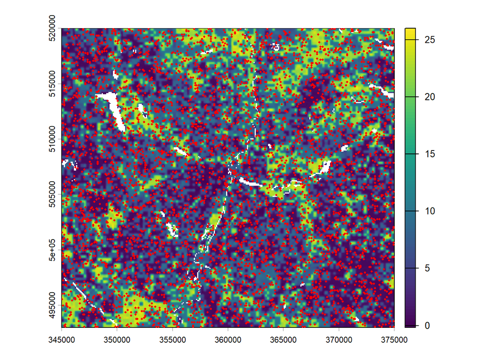

```r
plot(r[[1]])
plot(smp, add = TRUE, cex = 0.4, col = "red")
```

Większość narzędzi czy modeli operuje na typowych strukturach danych takich jak macierze czy ramki danych (niekoniecznie pliki rastrowe czy wektorowe). Z tego powodu dokonamy konwersji punktów (klasa `SpatVector`) na ramkę danych wykorzystując funkcję `as.data.frame()`.

```r
# konwersja punktów na ramkę danych
df_smp = as.data.frame(smp)
```

Następnie dane z próby należy zestandaryzować do wspólnej skali przy użyciu funkcji `scale()`. Istotną czynnością jest zapisane współczynników centrowania i skalowania z próby, ponieważ będzie trzeba je później zastosować dla całych rastrów (wszystkich komórek).

```r
# standaryzacja próby
df_smp_scale = scale(df_smp, center = TRUE, scale = TRUE)
# współczynnik centrowania
v_center = attr(df_smp_scale, "scaled:center")
# współczynnik skalowania
v_scale = attr(df_smp_scale, "scaled:scale")
```

Po standaryzacji danych możemy obliczyć główne składowe za pomocą poznanej już funkcji `prcomp()`.

```r
pca = prcomp(df_smp_scale, center = FALSE, scale. = FALSE)
```

Po wyznaczeniu głównych składowych, przechodzimy do najtrudniejszego etapu, polegającego na ekstrapolacji wyliczonych głównych składowych z próby na cały raster. Zasadniczo, tę procedurę przeprowadza się sekwencyjnie z podziałem na mniejsze bloki rastra, jednakże nasze rastry są małe i możemy je wczytać całe do pamięci.

Ponownie wykorzystajmy funkcję `as.data.frame()`, aby dokonać konwersji rastrów (`SpatRaster`) do ramki danych. Ustawmy także argument `na.rm = FALSE` do zachowania pustych wartości w rastrze. Następnie, kluczowym krokiem jest wyznaczenie indeksów komórek, które posiadają wartości używając funkcji `complete.cases()`, ponieważ będzie to niezbędne do wstawienia wartości w odpowiednie miejsca w wektorze.

```r
df = as.data.frame(r, na.rm = FALSE)
# indeksy komórek z wartościami
idx = complete.cases(df)
# usuń puste wartości
df = df[idx, ]
```

Tak jak wcześniej, standaryzujemy całe dane, z tą różnicą, iż definiujemy uprzednio wyliczone współczynniki centrowania (`v_center`) i skalowania (`v_scale`).

```r
# standaryzacja całego zbioru
df = scale(df, center = v_center, scale = v_scale)
```

Mamy już przygotowane dane, teraz możemy wykonać ekstrapolację używając funkcji `predict()` i podając dwa wymagane argumenty. Pierwszy to obliczone składowe główne w obiekcie `pca`, a drugi obiekt to ramka danych `df`.

```r
# PCA dla całego zbioru danych
pr = predict(pca, df)
```

Wynikiem powyższej predykcji jest macierz, w której w wierszach znajdują się komórki rastra (blisko 80 tysięcy), a w kolumnach składowe główne. Zauważ, że raster wejściowy składa się z 81 tysięcy komórek, natomiast z predykcji otrzymaliśmy ich mniej, co spowodowane jest wykluczeniem brakujących wartości. Rozwiązanie tego problemu jest proste. Należy wstawić wartości predykcji tylko w tych komórkach, które posiadały wartości.

Stwórzmy zatem nowy wektor zawierający wyłącznie brakujące wartości `NA` o takiej długości, ile raster posiada wszystkich komórek (270 * 300). Następnie używając indeksów z obiektu `idx` przypiszemy wartości pierwszej głównej składowej do wektora `vec` w odpowiednich miejscach.

```r
# stwórz pusty wektor
vec = rep(NA, ncell(r))
# przypisz wartości z PC1
vec[idx] = pr[, 1]
```

Następnie tworzymy nowy raster o nazwie `output` kopiując metadane z rastra `r` oraz definiując jeden kanał i wartości na podstawie wektora `vec`.

```r
# stwórz nowy raster
output = rast(r, nlyrs = 1, vals = vec)
```

Finalnie, dokonajmy wizualizacji pierwszej głównej składowej (PC1) na mapie.

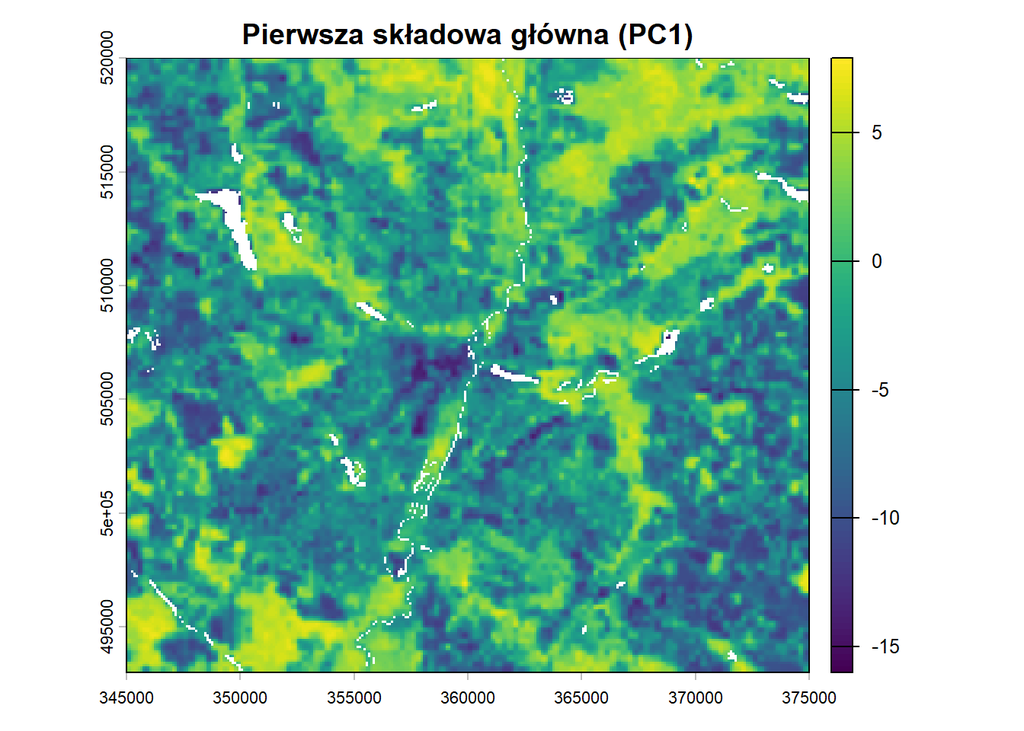

```r
plot(output, main = "Pierwsza składowa główna (PC1)")
```

# Zadanie

Dokonaj redukcji wymiarowości rastrów znajdujących się w katalogu `dane` używając analizy głównych składowych (*PCA*) i losowej próby. Przed analizą przygotuj odpowiednio dane wejściowe:

- usuń brakujące wartości (`NA`),
- zidentyfikuj wartości odstające i podejmij odpowiednie działania (np. usunięcie, nadpisanie czy transformacja rozkładu),
- pamiętaj o standaryzacji zmiennych.

Finalnym wynikiem analizy jest mapa przedstawiająca pierwszą główną składową wraz z interpretacją, co ona przedstawia. W raporcie należy wyjaśnić i uzasadnić wybór zastosowanych metod analitycznych.

Jako rozwiązanie należy przesłać:

- Działający plik źródłowy (np. Quarto `.qmd` lub RMarkdown `.Rmd`).
- Wygenerowany raport z wynikami przeprowadzonej analizy, rycinami oraz wnioskami (np. `.html` lub `.pdf`). Uwaga: Jeśli generujesz raport w formacie `.html`, to pamiętaj osadzić wszystkie niezbędne pliki.